# Tugas Praktikum 3 MPDW

David Fauzan Akmal

2024-09-09

## Impor Data

Data yang digunakan adalah data jumlah pelanggan dan pendapatan aplikasi streaming Netflix yang saya peroleh dari businessofapps.com. Jumlah pelanggan sebagai variabel independen dan jumlah pendapatan sebagai variabel dependen.

```r
dtNetflix <- read_excel("C://Users/USER/Downloads/Data Pelanggan dan Pendapatan Netflix.xlsx")
  Yt = dtNetflix$'Pendapatan (Juta Dolar)'
  Xt = dtNetflix$'Pelanggan (Juta)'

data = data.frame(Yt, Xt)
data
```

```
##      Yt     Xt
## 1   822  21.50
## 2   876  21.16
## 3   870  24.43
## 4   889  25.71
## 5   905  27.49
## 6   945  30.36
## 7  1024  34.24
## 8  1069  35.64
## 9  1106  38.01
## 10 1175  41.43
## 11 1270  46.13
## 12 1340  47.99
## 13 1409  50.65
## 14 1485  54.48
```

[output cut: 37 more lines]

## Pembagian Data

```r
#SPLIT DATA
train<-data[1:38,]
test<-data[39:51,]
```

```r
#data time series
train.ts<-ts(train)
test.ts<-ts(test)
data.ts<-ts(data)
```

## Model Koyck

Model Koyck didasarkan pada asumsi bahwa semakin jauh jarak lag peubah independen dari periode sekarang maka semakin kecil pengaruh peubah lag terhadap peubah dependen.

Koyck mengusulkan suatu metode untuk menduga model dinamis distributed lag dengan mengasumsikan bahwa semua koefisien $\beta$ mempunyai tanda sama.

Model kyock merupakan jenis paling umum dari model infinite distributed lag dan juga dikenal sebagai geometric lag

$$y_t=a(1-\lambda)+\beta_0X_t+\beta_1Z_t+\lambda Y_{t-1}+V_t$$

dengan
$$V_t=u_t-\lambda
u_{t-1}$$

### Pemodelan

Fungsi `koyckDlm()` akan menerapkan model lag terdistribusi dengan transformasi Koyck satu prediktor. Nilai `x` dan `y` tidak perlu sebagai objek *time series* (`ts`). `intercept` dapat dibuat `TRUE` untuk memasukkan intersep ke dalam model.

```r
#MODEL KOYCK
model.koyck <- koyckDlm(x = train$Xt, y = train$Yt)
summary(model.koyck)
```

```
##
## Call:
## "Y ~ (Intercept) + Y.1 + X.t"
##
## Residuals:
##      Min       1Q   Median       3Q      Max
## -124.218  -29.631   -4.896   13.114  188.341
##
## Coefficients:
##              Estimate Std. Error t value Pr(>|t|)
## (Intercept) -31.20660   23.00127  -1.357  0.18381
## Y.1           0.88294    0.05103  17.301  < 2e-16 ***
## X.t           5.40383    1.59706   3.384  0.00182 **
## ---
## Signif. codes:  0 '***' 0.001 '**' 0.01 '*' 0.05 '.' 0.1 ' ' 1
##
## Residual standard error: 61.32 on 34 degrees of freedom
## Multiple R-Squared: 0.9989,  Adjusted R-squared: 0.9989
## Wald test: 1.576e+04 on 2 and 34 DF,  p-value: < 2.2e-16
##
## Diagnostic tests:
## NULL
##
##                              alpha     beta       phi
## Geometric coefficients:  -266.5925 5.403833 0.8829427
```

```r
AIC(model.koyck)
```

```
## [1] 414.4683
```

```r
BIC(model.koyck)
```

```
## [1] 420.912
```

### Peramalan dan Akurasi

Berikut adalah hasil peramalan y untuk 13 periode kedepan menggunakan model koyck

```r
fore.koyck <- forecast(model = model.koyck, x=test$Xt, h=13)
fore.koyck
```

```
## $forecasts
##  [1] 6957.117 7241.903 7452.175 7747.423 8007.030 8231.006 8441.841 8669.390
##  [9] 8879.759 9097.332 9336.774 9619.139 9918.816
##
## $call
## forecast.koyckDlm(model = model.koyck, x = test$Xt, h = 13)
##
## attr(,"class")
## [1] "forecast.koyckDlm" "dLagM"
```

```r
mape.koyck <- MAPE(fore.koyck$forecasts, test$Yt)
#akurasi data training
GoF(model.koyck)
```

```
##              n      MAE          MPE       MAPE      sMAPE      MASE      MSE
## model.koyck 37 40.97226 0.0004422358 0.01623528 0.01632449 0.2551905 3455.605
##                  MRAE     GMRAE
## model.koyck 0.3056927 0.1994834
```

## Regression with Distributed Lag

Pemodelan model Regression with Distributed Lag dengan `R` dapat menggunakan `dLagM::dlm()` . Fungsi umum dari `dlm` adalah sebagai berikut.

```r
dlm(formula , data , x , y , q , remove )
```

Fungsi `dlm()` akan menerapkan model lag terdistribusi dengan satu atau lebih prediktor. Nilai `x` dan `y` tidak perlu sebagai objek *time series* (`ts`). $q$ adalah integer yang mewakili panjang *lag* yang terbatas.

### Pemodelan (Lag=2)

```r
model.dlm <- dlm(x = train$Xt,y = train$Yt , q = 2)
summary(model.dlm)
```

```
##
## Call:
## lm(formula = model.formula, data = design)
##
## Residuals:
##     Min      1Q  Median      3Q     Max
## -282.61 -159.70   27.08  150.41  312.25
##
## Coefficients:
##             Estimate Std. Error t value Pr(>|t|)
## (Intercept)  -218.66      66.80  -3.273  0.00255 **
## x.t            11.57      13.66   0.847  0.40327
## x.1             6.88      19.60   0.351  0.72786
## x.2            16.19      14.00   1.157  0.25597
## ---
## Signif. codes:  0 '***' 0.001 '**' 0.01 '*' 0.05 '.' 0.1 ' ' 1
##
## Residual standard error: 185 on 32 degrees of freedom
## Multiple R-squared:  0.9905, Adjusted R-squared:  0.9896
## F-statistic:  1108 on 3 and 32 DF,  p-value: < 2.2e-16
##
## AIC and BIC values for the model:
##        AIC      BIC
## 1 483.7992 491.7168
```

```r
AIC(model.dlm)
```

```
## [1] 483.7992
```

```r
BIC(model.dlm)
```

```
## [1] 491.7168
```

Dari hasil diatas, didapat bahwa $P-value$ dari intercept $<0.05$. Hal ini menunjukkan bahwa intercept berpengaruh signifikan terhadap $y$. Adapun model keseluruhan yang terbentuk adalah sebagai berikut

$$\hat{Y_t}=-218.66+11.57X_t+6.88X_{t-1}+16.19X_{t-2}$$

### Peramalan dan Akurasi

Berikut merupakan hasil peramalan $y$ untuk 13 periode kedepan

```r
fore.dlm <- forecast(model = model.dlm, x=test$Xt, h=13)
fore.dlm
```

```
## $forecasts
##  [1] 6745.179 6928.193 6915.082 7122.226 7136.039 7451.862 7469.948 7559.512
##  [9] 7671.650 7875.884 8046.097 8353.660 8693.687
##
## $call
## forecast.dlm(model = model.dlm, x = test$Xt, h = 13)
##
## attr(,"class")
## [1] "forecast.dlm" "dLagM"
```

```r
mape.dlm <- MAPE(fore.dlm$forecasts, test$Yt)
#akurasi data training
GoF(model.dlm)
```

```
##            n      MAE       MPE       MAPE      sMAPE      MASE      MSE
## model.dlm 36 153.8193 0.0186055 0.08764343 0.09301292 0.9323998 30430.82
##               MRAE     GMRAE
## model.dlm 2.022981 0.9954661
```

### *Lag* Optimum

```r
#penentuan lag optimum
finiteDLMauto(formula = Yt ~ Xt,
              data = data.frame(train), q.min = 1, q.max = 20,
              model.type = "dlm", error.type = "AIC", trace = FALSE)
```

```
##    q - k MASE  AIC  BIC GMRAE MBRAE R.Adj.Sq Ljung-Box
## 18    18    0 -Inf -Inf     0     0      NaN       NaN
```

Berdasarkan output tersebut, lag optimum didapatkan ketika lag=17 karena di lag 18 nilainya inf. Selanjutnya dilakukan pemodelan untuk lag=17

```r
#model dlm dengan lag optimum
model.dlm2 <- dlm(x = train$Xt,y = train$Yt , q = 17)
summary(model.dlm2)
```

```
##
## Call:
## lm(formula = model.formula, data = design)
##
## Residuals:
##        1        2        3        4        5        6        7        8
##   1.8359 -15.8271 -80.5305  11.7521  97.1596  -6.3488 -14.6440 -14.6502
##        9       10       11       12       13       14       15       16
##   0.4457  29.2329  32.5888 -10.4646 -43.5578   4.8522  31.2949   8.3482
##       17       18       19       20       21
## -27.6227  -3.7884   9.4655   4.2251 -13.7668
##
## Coefficients:
##             Estimate Std. Error t value Pr(>|t|)
## (Intercept) 1906.173   2586.119   0.737    0.538
## x.t          -23.787     45.560  -0.522    0.654
## x.1           20.914     38.247   0.547    0.639
## x.2           -1.633     36.819  -0.044    0.969
## x.3          -24.948     35.488  -0.703    0.555
## x.4          -22.828     92.280  -0.247    0.828
## x.5           -7.044     53.375  -0.132    0.907
## x.6          -36.436     48.913  -0.745    0.534
## x.7          -36.484     46.349  -0.787    0.514
## x.8           35.566    100.731   0.353    0.758
## x.9           27.286     45.682   0.597    0.611
## x.10         -21.319     44.920  -0.475    0.682
## x.11          -1.413     70.245  -0.020    0.986
## x.12         -16.881     59.901  -0.282    0.805
## x.13         -21.375     66.838  -0.320    0.779
## x.14          80.504     76.412   1.054    0.403
## x.15          84.749     74.489   1.138    0.373
## x.16          81.128    248.439   0.327    0.775
## x.17          17.714     52.292   0.339    0.767
##
## Residual standard error: 106.9 on 2 degrees of freedom
## Multiple R-squared:  0.9995, Adjusted R-squared:  0.9953
## F-statistic: 234.3 on 18 and 2 DF,  p-value: 0.004259
##
## AIC and BIC values for the model:
##        AIC      BIC
## 1 246.4377 267.3282
```

```r
AIC(model.dlm2)
```

```
## [1] 246.4377
```

```r
BIC(model.dlm2)
```

```
## [1] 267.3282
```

Dari hasil tersebut, tidak ada peubah yang berpengaruh signifikan pada taraf nyata 5%. Adapun keseluruhan model yang terbentuk adalah

$$\hat{Y_t}=1906.173+-23.787X_t+...+17.714X_{t-17}$$

Adapun hasil peramalan 13 periode kedepan menggunakan model tersebut adalah sebagai berikut

```r
#peramalan dan akurasi
fore.dlm2 <- forecast(model = model.dlm2, x=test$Xt, h=13)
mape.dlm2<- MAPE(fore.dlm2$forecasts, test$Yt)
#akurasi data training
GoF(model.dlm2)
```

```
##             n      MAE           MPE        MAPE       sMAPE       MASE     MSE
## model.dlm2 21 22.01913 -0.0003225711 0.007269348 0.007271057 0.09134674 1088.43
##                 MRAE      GMRAE
## model.dlm2 0.1197079 0.05935668
```

## Model Autoregressive

Peubah dependen dipengaruhi oleh peubah independen pada waktu sekarang, serta dipengaruhi juga oleh peubah dependen itu sendiri pada satu waktu yang lalu maka model tersebut disebut *autoregressive* (Gujarati 2004).

### Pemodelan

Pemodelan Autoregressive dilakukan menggunakan fungsi `dLagM::ardlDlm()` . Fungsi tersebut akan menerapkan *autoregressive* berordo $(p,q)$ dengan satu prediktor. Fungsi umum dari `ardlDlm()` adalah sebagai berikut.

```r
ardlDlm(formula = NULL , data = NULL , x = NULL , y = NULL , p = 1 , q = 1 ,
         remove = NULL )
```

Dengan $p$ adalah integer yang mewakili panjang *lag* yang terbatas dan $q$ adalah integer yang merepresentasikan ordo dari proses *autoregressive*.

```r
model.ardl <- ardlDlm(formula = Yt ~ Xt, data = train,p = 1 , q = 1)
summary(model.ardl)
```

```
##
## Time series regression with "ts" data:
## Start = 2, End = 38
##
## Call:
## dynlm(formula = as.formula(model.text), data = data)
##
## Residuals:
##      Min       1Q   Median       3Q      Max
## -124.734  -29.242   -5.369   13.457  191.320
##
## Coefficients:
##              Estimate Std. Error t value Pr(>|t|)
## (Intercept) -29.40702   22.95459  -1.281    0.209
## Xt.t          4.15693    4.50267   0.923    0.363
## Xt.1          1.28572    4.93390   0.261    0.796
## Yt.1          0.88332    0.05128  17.226   <2e-16 ***
## ---
## Signif. codes:  0 '***' 0.001 '**' 0.01 '*' 0.05 '.' 0.1 ' ' 1
##
## Residual standard error: 62.17 on 33 degrees of freedom
## Multiple R-squared:  0.9989, Adjusted R-squared:  0.9988
## F-statistic: 1.022e+04 on 3 and 33 DF,  p-value: < 2.2e-16
```

Hasil di atas menunjukkan bahwa selain peubah $y_{t-1}$, hasil uji t menunjukkan nilai-p pada peubah $\ge0.05$ Hal ini menunjukkan bahwa peubah $y_{t-1}$ berpengaruh signifikan terhadap $y_t$, sementara intercept, $x_t$, dan $x_{t-1}$ tidak berpengaruh signifikan terhadap $y_t$. Model keseluruhannya adalah sebagai berikut:

$$\hat{Y}=-29.40702+4.15693X_t+1.28572X_{t-1}+0.88332Y_{t-1}$$

### Peramalan dan Akurasi

```r
fore.ardl <- forecast(model = model.ardl, x=test$Xt, h=13)
fore.ardl
```

```
## $forecasts
##  [1] 6964.339 7258.818 7489.240 7767.281 8038.122 8273.071 8489.418 8715.474
##  [9] 8932.276 9150.515 9387.277 9662.256 9960.773
##
## $call
## forecast.ardlDlm(model = model.ardl, x = test$Xt, h = 13)
##
## attr(,"class")
## [1] "forecast.ardlDlm" "dLagM"
```

Data di atas merupakan hasil peramalan untuk 13 periode ke depan menggunakan Model Autoregressive dengan $p=1$ dan $q=1$.

```r
mape.ardl <- MAPE(fore.ardl$forecasts, test$Yt)
mape.ardl
```

```
## [1] 0.05816219
```

```r
#akurasi data training
GoF(model.ardl)
```

```
##             n      MAE          MPE       MAPE      sMAPE      MASE      MSE
## model.ardl 37 40.91172 0.0003634735 0.01612194 0.01620543 0.2548135 3447.593
##                MRAE     GMRAE
## model.ardl 0.298288 0.1952774
```

Berdasarkan akurasi di atas, terlihat bahwa nilai MAPE keduanya tidak jauh berbeda. Artinya, model regresi dengan distribusi lag ini tidak `overfitted` atau `underfitted`

### *Lag* Optimum

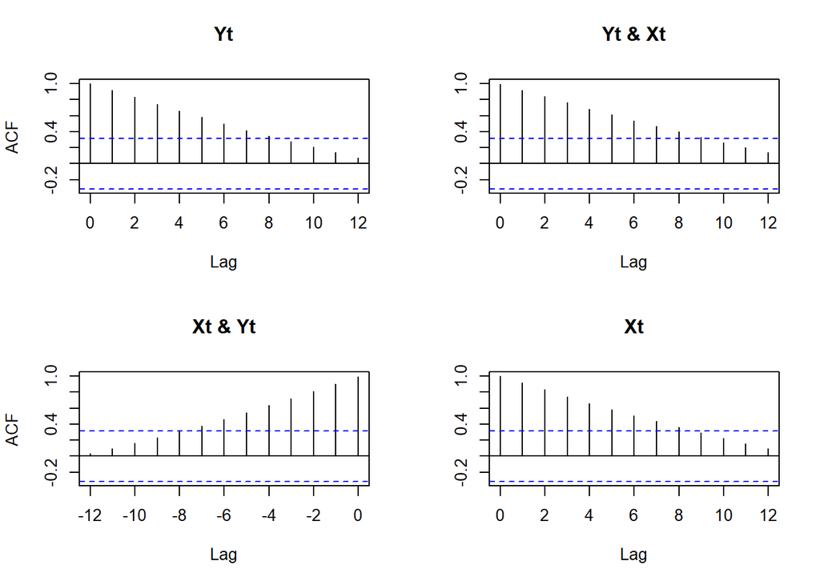

```r
acf(train)
```

```r
model.ardl.opt <- ardlBoundOrders(data = data.frame(data), ic = "AIC",
                                  formula = Yt ~ Xt )
```

### Mencari nilai q (Lag Peubah X)

```r
stattable = model.ardl.opt$Stat.table
stattable
```

```
##           q = 1    q = 2    q = 3    q = 4    q = 5    q = 6    q = 7    q = 8
## p = 1  586.7998 575.7297 565.5930 556.1464 545.6219 535.9325 525.8504 514.6262
## p = 2  577.4977 577.5043 567.5068 558.1167 547.4588 537.1661 525.9377 514.7224
## p = 3  568.4363 568.4363 569.4211 560.0009 549.2681 539.1177 527.7213 516.3792
## p = 4  560.7492 560.0231 560.0231 561.9510 551.2267 541.0609 528.6614 515.0146
## p = 5  542.4032 537.1580 538.5354 538.5354 538.8348 529.5366 516.4579 506.0298
## p = 6  532.7789 530.2094 529.6232 529.4423 529.4423 531.4209 518.4020 507.9830
## p = 7  520.8928 521.3018 520.6353 520.8760 522.8410 522.8410 520.4007 509.9694
## p = 8  511.1772 511.4464 509.7991 511.4067 512.2723 510.6464 510.6464 511.9354
## p = 9  495.6820 495.6766 495.1218 493.4268 492.2260 491.8374 492.5310 492.5310
## p = 10 478.8721 480.6667 481.1429 476.4236 475.6624 476.0362 474.0494 470.5383
## p = 11 467.7287 469.6336 470.7365 465.4493 464.3874 465.4917 463.3928 461.2547
## p = 12 457.1999 459.1754 459.5602 456.9090 452.6922 449.2248 451.2236 439.2351
## p = 13 443.4186 445.4118 444.1763 436.5135 422.3275 423.2010 423.8722 413.7031
## p = 14 432.1461 433.9695 433.0048 429.4719 412.8615 414.6425 414.7836 400.2482
## p = 15 415.4580 417.3907 418.5176 416.1715 401.1335 402.8450 400.0150 385.1970
##           q = 9   q = 10   q = 11   q = 12   q = 13   q = 14   q = 15
## p = 1  496.7744 485.7361 469.1031 459.8012 433.4709 421.3760 411.8398
## p = 2  494.8428 480.9523 464.9407 452.8723 425.4015 409.3165 399.3784
## p = 3  496.5067 482.0442 464.2786 451.4595 426.5576 409.4558 400.3068
## p = 4  496.4744 482.5150 465.1121 452.2539 425.3256 411.4541 402.2586
## p = 5  493.7227 480.4825 462.6951 450.9473 427.3055 413.2294 404.1041
## p = 6  492.7550 480.5796 459.1956 449.3913 427.2004 411.7990 401.8477
## p = 7  494.6407 480.0923 461.1299 451.3230 426.2455 408.3894 398.0013
## p = 8  495.8890 480.7321 458.8625 444.4186 411.7515 392.2355 384.7965
## p = 9  489.3265 475.8817 456.2372 439.5848 404.1729 387.1233 380.8934
## p = 10 470.5383 471.3228 447.4600 425.1278 405.6323 388.8739 382.4844
## p = 11 463.2310 463.2310 449.3946 423.1432 406.2443 388.8748 379.6608
## p = 12 440.8000 420.6963 420.6963 422.6832 405.7291 390.8377 380.9551
## p = 13 415.2709 414.6470 409.0354 409.0354 402.5797 391.6379 370.9338
## p = 14 402.1276 401.6227 394.2846 384.2086 384.2086 385.5463 369.8670
## p = 15 381.6769 371.4691 363.8594 364.4412 356.1676 356.1676 353.5480
```

Dari tabel di atas, dapat dilihat di baris p = 9 bahwa nilai q di bawah 14 dengan AIC paling rendah adalah q = 13. Setelah lag 15, hanya bisa dipakai 23 data, sehingga jumlah p+q tidak boleh melebihi 23. Oleh karena itu, di sini dicari lag dari peubah x (q) yang di bawah 14.

## Cek Akurasi dengan p = 9 dan q = 13

```r
modelardl.baru <- ardlDlm(formula = Yt ~ Xt, data = train,p = 9 , q = 13)
GoF(modelardl.baru)
```

```
##                 n      MAE           MPE        MAPE       sMAPE       MASE
## modelardl.baru 25 3.337505 -1.389248e-06 0.001395098 0.001395509 0.01552629
##                     MSE       MRAE      GMRAE
## modelardl.baru 18.73204 0.02357028 0.01097754
```

Selanjutnya dapat dilakukan pemodelan dengan nilai $p$ dan $q$ optimum seperti inisialisasi di langkah sebelumnya.

## Pemodelan DLM & ARDL dengan Library `dynlm`

Pemodelan regresi dengan peubah *lag* tidak hanya dapat dilakukan dengan fungsi pada *packages* `dLagM` , tetapi terdapat *packages* `dynlm` yang dapat digunakan. Fungsi `dynlm` secara umum adalah sebagai berikut.

```r
dynlm(formula, data, subset, weights, na.action, method = "qr",
  model = TRUE, x = FALSE, y = FALSE, qr = TRUE, singular.ok = TRUE,
  contrasts = NULL, offset, start = NULL, end = NULL, ...)
```

Untuk menentukan `formula` model yang akan digunakan, tersedia fungsi tambahan yang memungkinkan spesifikasi dinamika (melalui `d()` dan `L()`) atau pola linier/siklus dengan mudah (melalui `trend()`, `season()`, dan `harmon()`). Semua fungsi formula baru mengharuskan argumennya berupa objek deret waktu (yaitu, `"ts"` atau `"zoo"`).

```r
#sama dengan model dlm q=13
cons_lm1 <- dynlm(Yt ~ Xt + L(Xt, 1) + L(Xt, 2) + L(Xt, 3) + L(Xt, 4) +
                        L(Xt, 5)+ L(Xt, 6)+ L(Xt, 7)+ L(Xt, 8)+ L(Xt, 9) +
                        L(Xt, 10) + L(Xt, 11) + L(Xt, 12) + L(Xt, 13), data=train.ts)

#sama dengan model ardl p=9 q=0
cons_lm2 <- dynlm(Yt ~ Xt + L(Yt, 1) + L(Yt, 2) + L(Yt, 3) + L(Yt, 4) +
                        L(Yt, 5) + L(Yt, 6) + L(Yt, 7) + L(Yt, 8) + L(Yt, 9), data = train.ts)

#sama dengan ardl p=9 q=13
cons_lm3 <- dynlm(Yt ~ Xt + L(Xt, 1) + L(Xt, 2) + L(Xt, 3) + L(Xt, 4) +
                        L(Xt, 5) + L(Xt, 6) + L(Xt, 7) + L(Xt, 8) + L(Xt, 9) + L(Xt, 10) + L(Xt, 11) + L(Xt, 12) + L(Yt, 13)+ L(Yt, 1) + L(Yt, 2) + L(Yt, 3) + L(Yt, 4) +
                        L(Yt, 5) + L(Yt, 6) + L(Yt, 7) + L(Yt, 8) + L(Yt, 9), data = train.ts)

#sama dengan dlm p=10
cons_lm4 <- dynlm(Yt ~ Xt + L(Yt, 1) + L(Yt, 2) + L(Yt, 3) + L(Yt, 4) +
                        L(Yt, 5) + L(Yt, 6) + L(Yt, 7) + L(Yt, 8) + L(Yt, 9) + L (Yt, 10), data=train.ts)
```

### Ringkasan Model

```r
summary(cons_lm1)
```

```
##
## Time series regression with "ts" data:
## Start = 14, End = 38
##
## Call:
## dynlm(formula = Yt ~ Xt + L(Xt, 1) + L(Xt, 2) + L(Xt, 3) + L(Xt,
##     4) + L(Xt, 5) + L(Xt, 6) + L(Xt, 7) + L(Xt, 8) + L(Xt, 9) +
##     L(Xt, 10) + L(Xt, 11) + L(Xt, 12) + L(Xt, 13), data = train.ts)
##
## Residuals:
##     Min      1Q  Median      3Q     Max
## -184.70  -56.00   15.72   43.93  143.72
##
## Coefficients:
##              Estimate Std. Error t value Pr(>|t|)
## (Intercept) -243.4724   588.7383  -0.414    0.688
## Xt            16.4388    23.0543   0.713    0.492
## L(Xt, 1)      -0.1370    24.3349  -0.006    0.996
## L(Xt, 2)     -14.3098    24.6566  -0.580    0.575
## L(Xt, 3)      27.0501    31.9929   0.846    0.418
## L(Xt, 4)      -1.9957    34.2994  -0.058    0.955
## L(Xt, 5)     -44.0955    38.8669  -1.135    0.283
## L(Xt, 6)      32.6098    34.7348   0.939    0.370
## L(Xt, 7)     -15.2707    40.9065  -0.373    0.717
## L(Xt, 8)      37.3391    45.6080   0.819    0.432
## L(Xt, 9)      -0.8065    44.6240  -0.018    0.986
## L(Xt, 10)     -1.8747    44.6027  -0.042    0.967
## L(Xt, 11)    -34.5661    52.0142  -0.665    0.521
## L(Xt, 12)    -25.8438    55.2432  -0.468    0.650
## L(Xt, 13)     78.8312    38.2030   2.063    0.066 .
## ---
## Signif. codes:  0 '***' 0.001 '**' 0.01 '*' 0.05 '.' 0.1 ' ' 1
##
## Residual standard error: 121.7 on 10 degrees of freedom
## Multiple R-squared:  0.9978, Adjusted R-squared:  0.9947
## F-statistic: 322.1 on 14 and 10 DF,  p-value: 2.422e-11
```

```r
summary(cons_lm2)
```

```
##
## Time series regression with "ts" data:
## Start = 10, End = 38
##
## Call:
## dynlm(formula = Yt ~ Xt + L(Yt, 1) + L(Yt, 2) + L(Yt, 3) + L(Yt,
##     4) + L(Yt, 5) + L(Yt, 6) + L(Yt, 7) + L(Yt, 8) + L(Yt, 9),
##     data = train.ts)
##
## Residuals:
##     Min      1Q  Median      3Q     Max
## -87.678 -14.873   1.214  12.770 106.512
##
## Coefficients:
##               Estimate Std. Error t value Pr(>|t|)
## (Intercept) -27.850984  45.348501  -0.614  0.54680
## Xt            4.801100   2.346735   2.046  0.05567 .
## L(Yt, 1)      1.577513   0.211855   7.446  6.7e-07 ***
## L(Yt, 2)     -1.339110   0.401567  -3.335  0.00369 **
## L(Yt, 3)      0.681811   0.503864   1.353  0.19275
## L(Yt, 4)      0.020684   0.526609   0.039  0.96910
## L(Yt, 5)      0.146527   0.525396   0.279  0.78351
## L(Yt, 6)      0.007297   0.527392   0.014  0.98911
## L(Yt, 7)     -0.279223   0.506144  -0.552  0.58796
## L(Yt, 8)      0.566858   0.435763   1.301  0.20972
## L(Yt, 9)     -0.543231   0.251456  -2.160  0.04448 *
## ---
## Signif. codes:  0 '***' 0.001 '**' 0.01 '*' 0.05 '.' 0.1 ' ' 1
##
## Residual standard error: 45.33 on 18 degrees of freedom
## Multiple R-squared:  0.9996, Adjusted R-squared:  0.9993
## F-statistic:  4136 on 10 and 18 DF,  p-value: < 2.2e-16
```

```r
summary(cons_lm3)
```

```
##
## Time series regression with "ts" data:
## Start = 14, End = 38
##
## Call:
## dynlm(formula = Yt ~ Xt + L(Xt, 1) + L(Xt, 2) + L(Xt, 3) + L(Xt,
##     4) + L(Xt, 5) + L(Xt, 6) + L(Xt, 7) + L(Xt, 8) + L(Xt, 9) +
##     L(Xt, 10) + L(Xt, 11) + L(Xt, 12) + L(Yt, 13) + L(Yt, 1) +
##     L(Yt, 2) + L(Yt, 3) + L(Yt, 4) + L(Yt, 5) + L(Yt, 6) + L(Yt,
##     7) + L(Yt, 8) + L(Yt, 9), data = train.ts)
##
## Residuals:
##       14       15       16       17       18       19       20       21
##  -6.6897   2.4859  31.2607 -12.0643 -31.7762  12.8065  -7.4372  13.9698
##       22       23       24       25       26       27       28       29
##   9.0428 -12.0435  -9.0594  -7.6256  16.9081   4.7779  -8.9103  -0.8043
##       30       31       32       33       34       35       36       37
##   7.6784  -3.0004  -4.6444   3.0971   9.6009  -6.3556   2.7850   2.2730
##       38
##  -6.2752
##
## Coefficients:
##               Estimate Std. Error t value Pr(>|t|)
## (Intercept) -664.59145 3294.63490  -0.202    0.873
## Xt            16.66626   47.45726   0.351    0.785
## L(Xt, 1)       6.61416   41.35353   0.160    0.899
## L(Xt, 2)      11.49224   61.94295   0.186    0.883
## L(Xt, 3)     -12.38549   94.24247  -0.131    0.917
## L(Xt, 4)      16.04126   70.16226   0.229    0.857
## L(Xt, 5)      32.13930   41.44933   0.775    0.580
## L(Xt, 6)     -48.46177   43.32626  -1.119    0.464
## L(Xt, 7)      35.24915   76.13494   0.463    0.724
## L(Xt, 8)      11.76036  160.34362   0.073    0.953
## L(Xt, 9)     -79.03081   51.25571  -1.542    0.366
## L(Xt, 10)     72.52674  127.36346   0.569    0.670
## L(Xt, 11)    -56.75530  184.75737  -0.307    0.810
## L(Xt, 12)    -18.26270  304.22958  -0.060    0.962
## L(Yt, 13)      0.36149    2.54198   0.142    0.910
## L(Yt, 1)       2.38256    1.14189   2.087    0.285
## L(Yt, 2)      -3.16335    3.02222  -1.047    0.485
## L(Yt, 3)       2.72015    4.03973   0.673    0.623
## L(Yt, 4)      -0.93634    5.54679  -0.169    0.894
## L(Yt, 5)      -0.32553    4.24243  -0.077    0.951
## L(Yt, 6)       0.64353    1.63414   0.394    0.761
## L(Yt, 7)      -0.14982    1.56642  -0.096    0.939
## L(Yt, 8)      -0.66000    2.74338  -0.241    0.850
## L(Yt, 9)      -0.03256    1.52128  -0.021    0.986
##
## Residual standard error: 60.31 on 1 degrees of freedom
## Multiple R-squared:  0.9999, Adjusted R-squared:  0.9987
## F-statistic: 799.6 on 23 and 1 DF,  p-value: 0.02791
```

```r
summary(cons_lm4)
```

```
##
## Time series regression with "ts" data:
## Start = 11, End = 38
##
## Call:
## dynlm(formula = Yt ~ Xt + L(Yt, 1) + L(Yt, 2) + L(Yt, 3) + L(Yt,
##     4) + L(Yt, 5) + L(Yt, 6) + L(Yt, 7) + L(Yt, 8) + L(Yt, 9) +
##     L(Yt, 10), data = train.ts)
##
## Residuals:
##     Min      1Q  Median      3Q     Max
## -87.371 -19.485   1.559  11.761 103.665
##
## Coefficients:
##              Estimate Std. Error t value Pr(>|t|)
## (Intercept) -46.51222   54.45449  -0.854   0.4056
## Xt            5.61414    2.73514   2.053   0.0568 .
## L(Yt, 1)      1.55474    0.25461   6.106 1.52e-05 ***
## L(Yt, 2)     -1.30785    0.46418  -2.818   0.0124 *
## L(Yt, 3)      0.62689    0.55173   1.136   0.2726
## L(Yt, 4)      0.05758    0.55258   0.104   0.9183
## L(Yt, 5)      0.14632    0.55704   0.263   0.7961
## L(Yt, 6)     -0.04788    0.55648  -0.086   0.9325
## L(Yt, 7)     -0.18340    0.55770  -0.329   0.7465
## L(Yt, 8)      0.46929    0.55439   0.846   0.4098
## L(Yt, 9)     -0.51763    0.50069  -1.034   0.3166
## L(Yt, 10)     0.01812    0.30344   0.060   0.9531
## ---
## Signif. codes:  0 '***' 0.001 '**' 0.01 '*' 0.05 '.' 0.1 ' ' 1
##
## Residual standard error: 47.35 on 16 degrees of freedom
## Multiple R-squared:  0.9996, Adjusted R-squared:  0.9992
## F-statistic:  3261 on 11 and 16 DF,  p-value: < 2.2e-16
```

### SSE

```r
deviance(cons_lm1)
```

```
## [1] 148010.9
```

```r
deviance(cons_lm2)
```

```
## [1] 36990.43
```

```r
deviance(cons_lm3)
```

```
## [1] 3637.698
```

```r
deviance(cons_lm4)
```

```
## [1] 35871.38
```

### Uji Diagnostik

```r
#uji model
#if(require("lmtest")) encomptest(cons_lm1, cons_lm2)
#Tidak dilakukan karena panjang cons_lm1 dan cons_lm2 berbeda. cons_lm1 lagnya 13 dan cons_lm2 lagnya 9 sehingga jumlah datanya berbeda.
```

#### Autokorelasi

```r
#durbin watson
dwtest(cons_lm1)
```

```
##
##  Durbin-Watson test
##
## data:  cons_lm1
## DW = 1.1837, p-value = 0.01578
## alternative hypothesis: true autocorrelation is greater than 0
```

```r
dwtest(cons_lm2)
```

```
##
##  Durbin-Watson test
##
## data:  cons_lm2
## DW = 1.8983, p-value = 0.1737
## alternative hypothesis: true autocorrelation is greater than 0
```

```r
dwtest(cons_lm3)
```

```
##
##  Durbin-Watson test
##
## data:  cons_lm3
## DW = 2.2591, p-value < 2.2e-16
## alternative hypothesis: true autocorrelation is greater than 0
```

```r
dwtest(cons_lm4)
```

```
##
##  Durbin-Watson test
##
## data:  cons_lm4
## DW = 1.9096, p-value = 0.1718
## alternative hypothesis: true autocorrelation is greater than 0
```

#### Heterogenitas

```r
bptest(cons_lm1)
```

```
##
##  studentized Breusch-Pagan test
##
## data:  cons_lm1
## BP = 13.811, df = 14, p-value = 0.4638
```

```r
bptest(cons_lm2)
```

```
##
##  studentized Breusch-Pagan test
##
## data:  cons_lm2
## BP = 12.465, df = 10, p-value = 0.2551
```

```r
bptest(cons_lm3)
```

```
##
##  studentized Breusch-Pagan test
##
## data:  cons_lm3
## BP = 24.945, df = 23, p-value = 0.3531
```

```r
bptest(cons_lm4)
```

```
##
##  studentized Breusch-Pagan test
##
## data:  cons_lm4
## BP = 13.798, df = 11, p-value = 0.2444
```

#### Kenormalan

```r
shapiro.test(residuals(cons_lm1))
```

```
##
##  Shapiro-Wilk normality test
##
## data:  residuals(cons_lm1)
## W = 0.98055, p-value = 0.8958
```

```r
shapiro.test(residuals(cons_lm2))
```

```
##
##  Shapiro-Wilk normality test
##
## data:  residuals(cons_lm2)
## W = 0.95606, p-value = 0.262
```

```r
shapiro.test(residuals(cons_lm3))
```

```
##
##  Shapiro-Wilk normality test
##
## data:  residuals(cons_lm3)
## W = 0.9569, p-value = 0.3562
```

```r
shapiro.test(residuals(cons_lm4))
```

```
##
##  Shapiro-Wilk normality test
##
## data:  residuals(cons_lm4)
## W = 0.95867, p-value = 0.3242
```

## Perbandingan Model

```r
akurasi <- matrix(c(mape.koyck, mape.dlm, mape.dlm2, mape.ardl))
row.names(akurasi)<- c("Koyck","DLM 1","DLM 2","Autoregressive")
colnames(akurasi) <- c("MAPE")
akurasi
```

```
##                      MAPE
## Koyck          0.05467899
## DLM 1          0.06170082
## DLM 2          0.61674180
## Autoregressive 0.05816219
```

Berdasarkan nilai MAPE, model paling optimum didapat pada Model Koyck karena memiliki nilai MAPE yang terkecil.

### Plot

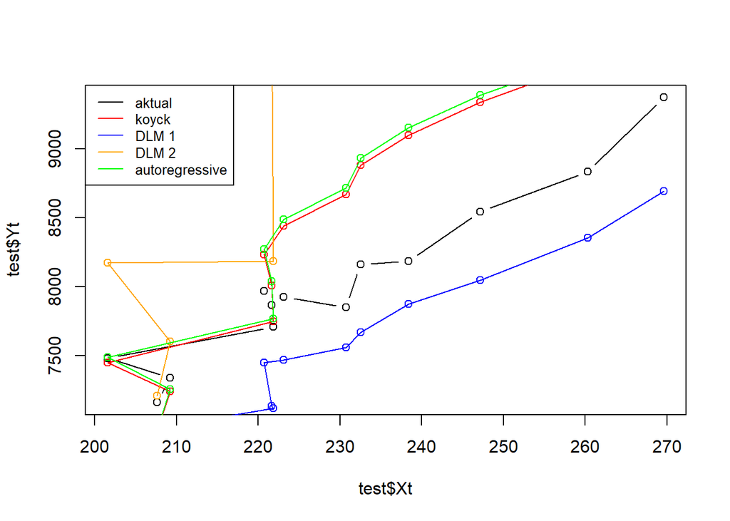

```r
par(mfrow=c(1,1))
plot(test$Xt, test$Yt, type="b", col="black")
points(test$Xt, fore.koyck$forecasts,col="red")
lines(test$Xt, fore.koyck$forecasts,col="red")
points(test$Xt, fore.dlm$forecasts,col="blue")
lines(test$Xt, fore.dlm$forecasts,col="blue")
points(test$Xt, fore.dlm2$forecasts,col="orange")
lines(test$Xt, fore.dlm2$forecasts,col="orange")
points(test$Xt, fore.ardl$forecasts,col="green")
lines(test$Xt, fore.ardl$forecasts,col="green")
legend("topleft",c("aktual", "koyck","DLM 1","DLM 2", "autoregressive"), lty=1, col=c("black","red","blue","orange","green"), cex=0.8)
```

Berdasarkan plot tersebut, terlihat bahwa plot yang paling mendekati data aktualnya adalah Model koyck, sehingga dapat disimpulkan model terbaik dalam hal ini adalah model regresi koyck